# gloBarAnalysis

ian enochs

2024-03-10

### GLOBAL BMU Analysis

This document was created to analyze NCRMP BMU data

## Summary of data

**Total number of BARs**

```
## [1] 620
```

```
## # A tibble: 2 × 4
##   basin    maxDays minDays     n
##   <chr>      <dbl>   <dbl> <int>
## 1 Atlantic    2373     956   343
## 2 Pacific     1879     906   277
```

```
## # A tibble: 10 × 4
##    region maxDays minDays     n
##    <chr>    <dbl>   <dbl> <int>
##  1 DRTO      1081    1043    10
##  2 FGB       1463    1220    13
##  3 FLK       2373     956   194
##  4 MARIAN    1879    1085   155
##  5 MHI       1094     906    42
##  6 PR        1798    1140    33
##  7 PRIA      1223    1063    80
##  8 STJ       1686    1632    16
##  9 STT       1950    1142    13
## 10 STX       1441    1090    64
```

## QA/QC of deltaMass_mgcm2y

**List tags where deltaMass_mgcm2y = “NA”:**

```
## numeric(0)
```

**Historgram of deltaMass_mgcm2y values**

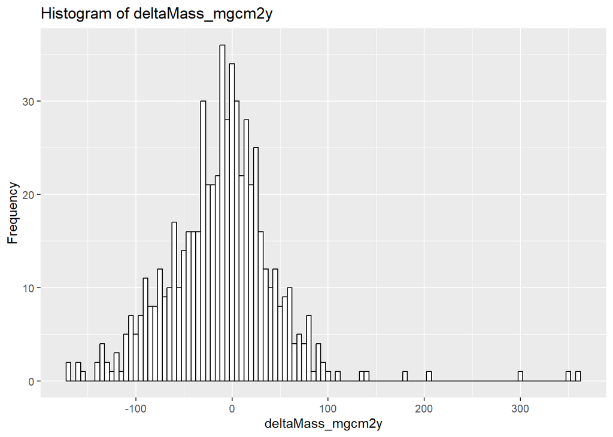

## QA/QC of deltaVolume_mm3cm2y

**List tags where deltaVolume_mm3cm2y = “NA”:**

```
##  [1] 2178 2181 2182 2183 2184 1321 1322 1323 1324 1325 4860 4861 4862 4863 4864
## [16] 4865 4866 4867 4869 4875 4877 4878 4870 4871 4872 4873 4881 4882 4883 4885
## [31] 4886 4887 4888 4889 4890 4891 4892 4893 4894 4896 4897 4898 4899 3263 3233
## [46] 3229 4723
```

**Historgram of deltaVolume_mm3cm2y values**

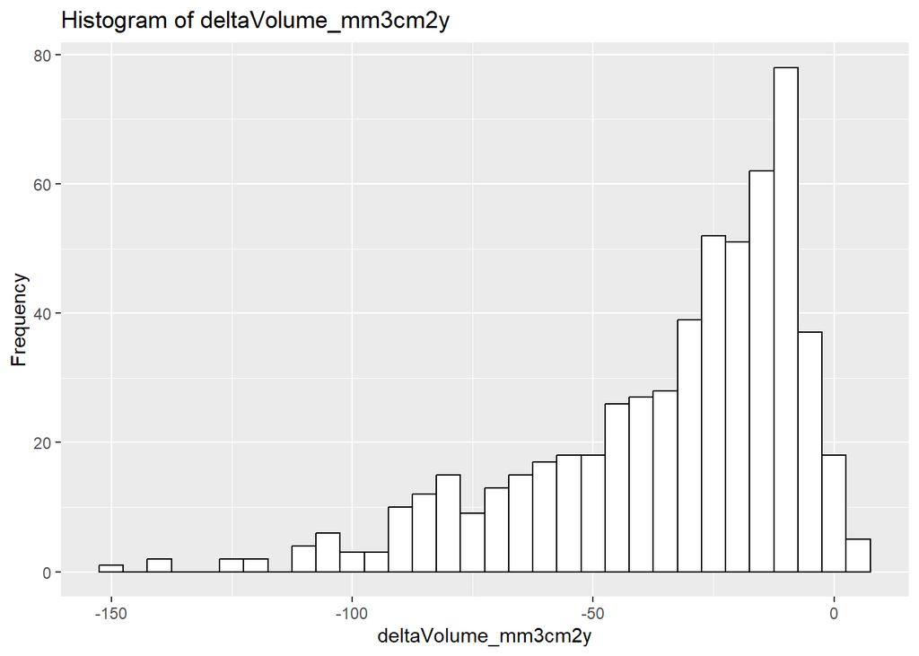

## QA/QC of deltaDensity_mgcm3cm2y

**List tags where deltaDensity_mgcm3cm2y = “NA”:**

```
##   [1] 4981 4982 4983 4984 4985 4980 1321 1322 1323 1324 1325 4860 4861 4862 4863
##  [16] 4864 4865 4866 4867 4869 4875 4877 4878 4870 4871 4872 4873 4881 4882 4883
##  [31] 4885 4886 4887 4888 4889 4890 4891 4892 4893 4894 4896 4897 4898 4899 1054
##  [46] 1058 1032 1033 1044 1051 1052 1055 1060 1034 1043 1046 1048 1053 1064 1065
##  [61] 1028 1030 1031 1035 1018 1021 1023 1024 1025 1026 1027 1012 1013 1015 1016
##  [76] 1019 1001 1002 1009 1010 1011 1074 1076 1005 1079 1081 1003 1004 1082 1008
##  [91] 1045 1083 1084 1085 1086 1087 1089 1090 1096 3263 3233 1080 1088 1091 1233
## [106] 3229 1094 1097 1231 1066 1067 1068 1069 1078 1093 1099 1232 3245 3247 4723
```

**Historgram of deltaDensity_mgcm3cm2y values**

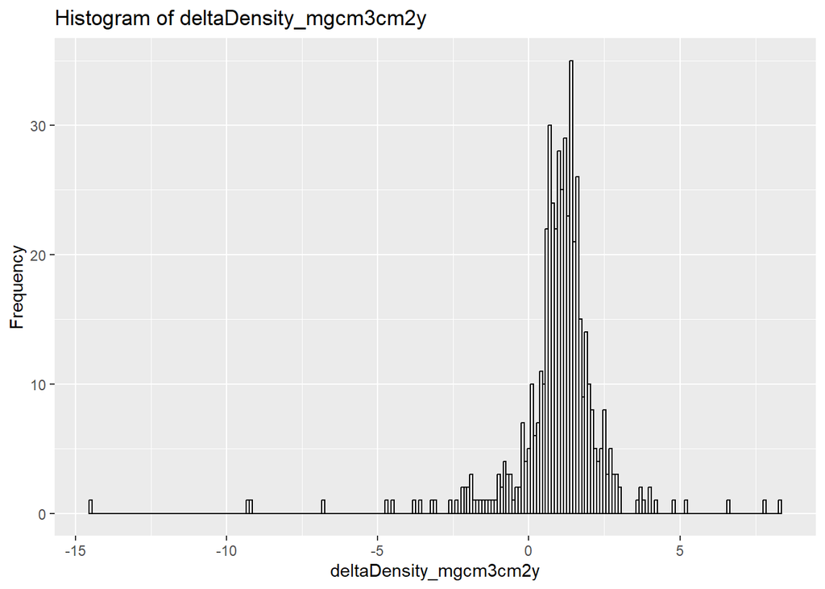

## QA/QC of macroboring_mm3cm2y

**List tags where macroboring_mm3cm2y = “NA”:**

```
## [1] 4925 4918 4922 6526 6530
```

**Historgram of macroboring_mm3cm2y values**

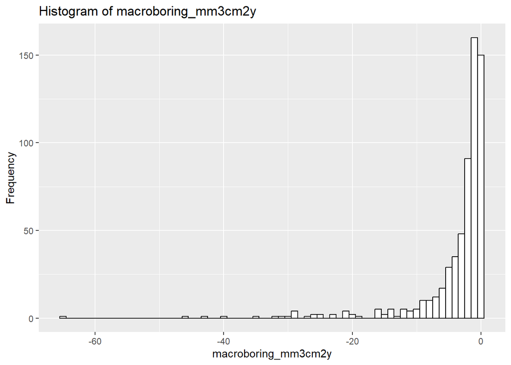

## QA/QC of accretion_mm3cm2y

**List tags where accretion_mm3cm2y = “NA”:**

```
## numeric(0)
```

**Historgram of accretion_mm3cm2y values**

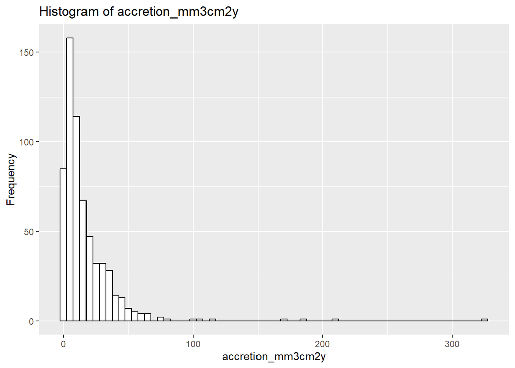

## QA/QC of grazing_mm3cm2y

**List tags where grazing_mm3cm2y = “NA”:**

```
##  [1] 2178 2181 2182 2183 2184 4925 4918 4922 1321 1322 1323 1324 1325 4860 4861
## [16] 4862 4863 4864 4865 4866 4867 4869 4875 4877 4878 4870 4871 4872 4873 4881
## [31] 4882 4883 4885 4886 4887 4888 4889 4890 4891 4892 4893 4894 4896 4897 4898
## [46] 4899 6526 6530 3263 3233 3229 4723
```

**List tags where grazing_mm3cm2y > 0 and list of those values:**

```
##  [1] 1058 1032 1044 1046 1018 1021 1003 1045 3252 3239 3243 3209
```

```
##  [1] 1.9166975 1.9034783 3.1911669 5.9639811 3.7476191 0.8993853 0.6138478
##  [8] 3.2214810 6.9731866 1.1439126 0.6225441 3.9642291
```

**Historgram of grazing_mm3cm2y values**

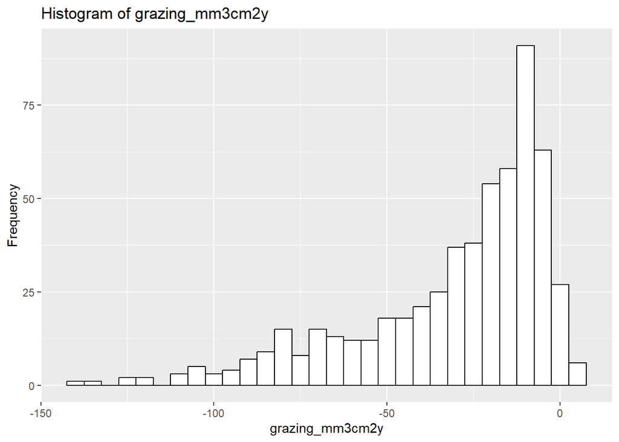

## General trends

**Plot of deltaVolume_mm3cm2y vs. deltaMass_mgcm2y:**

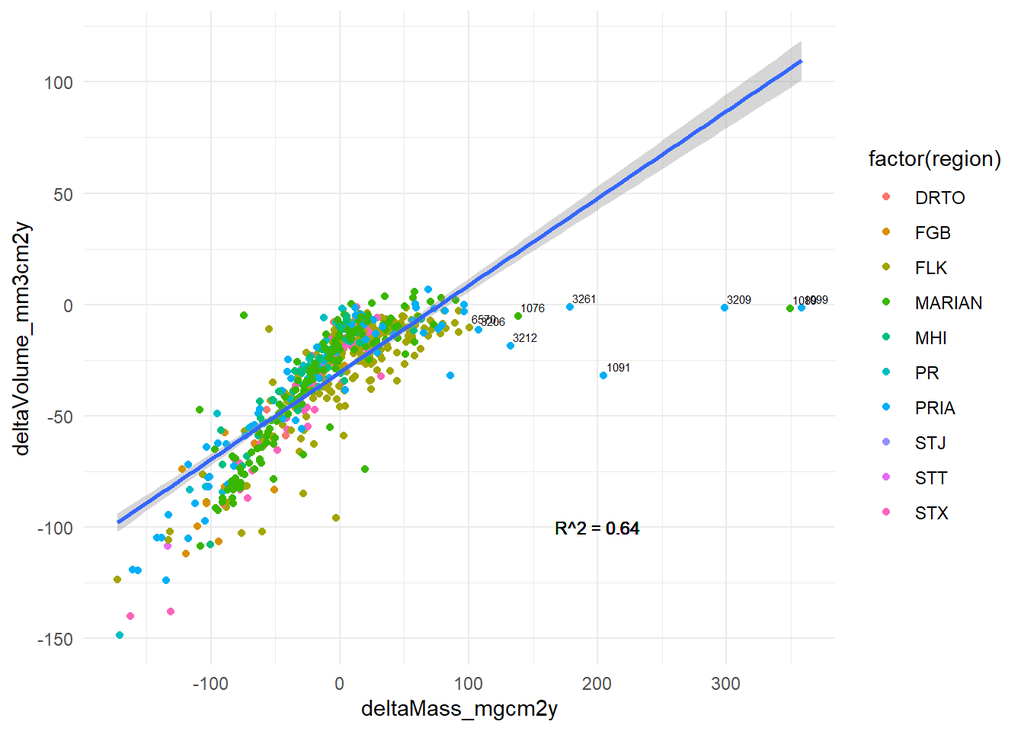

**Plot of deltaMass_mgcm2y vs. daysDeployed:**

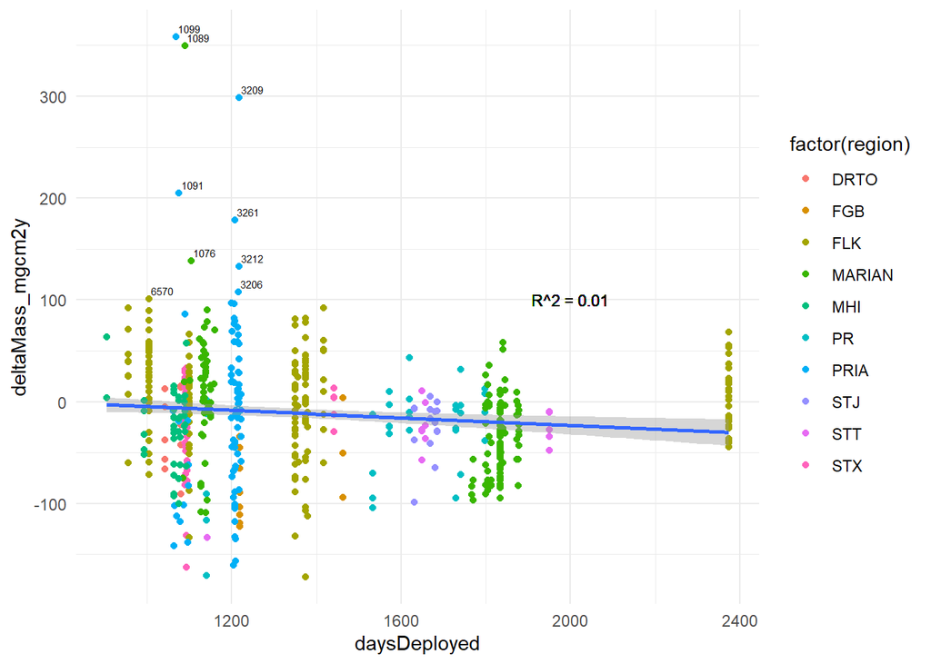

**Grazing vs. Accretion**

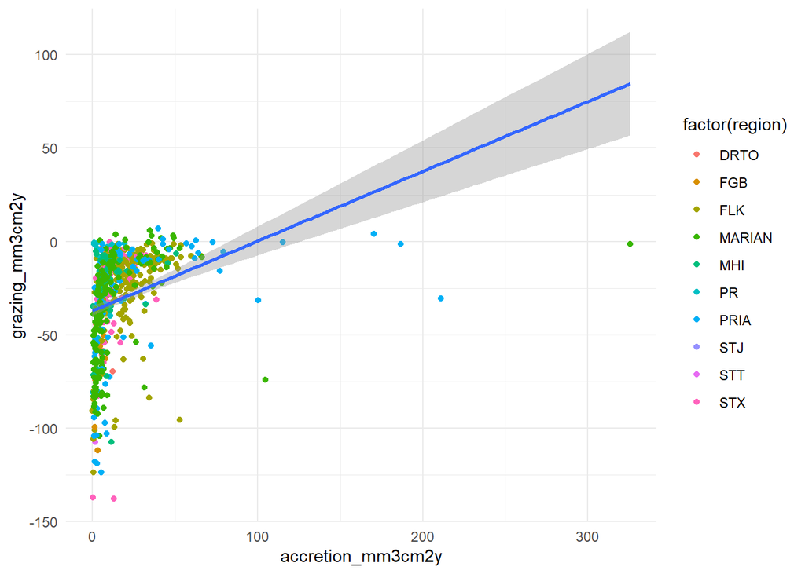

**deltaMass_mgcm2y vs. grazing_mm3cm2y**

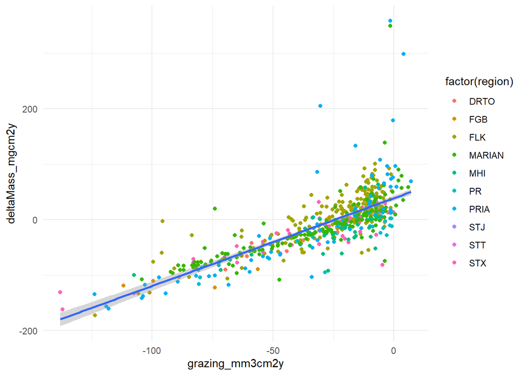

```
## # A tibble: 71 × 10
## # Groups:   basin, region [8]
##    basin    region siteName      meanGrazing sdGrazing seGrazing meanDeltaMass
##    <chr>    <chr>  <chr>               <dbl>     <dbl>     <dbl>         <dbl>
##  1 Atlantic DRTO   Bird Key Reef       -31.3     26.3       8.31        -28.0
##  2 Atlantic FGB    East Buoy 3         -68.8     25.3       7.64        -76.5
##  3 Atlantic FLK    Cheeca Rocks        -24.1     16.4       3.97          7.84
##  4 Atlantic FLK    LKI1                -21.0     11.8       3.93         10.4
##  5 Atlantic FLK    LKI2                -12.8      9.44      3.34          1.28
##  6 Atlantic FLK    LKO1                -21.7     15.5       4.90          6.14
##  7 Atlantic FLK    LKO2                -14.6     22.4       5.14         26.5
##  8 Atlantic FLK    MKI1                -14.5      7.83      1.85         31.2
##  9 Atlantic FLK    MKI2                -37.1     29.4       6.57        -23.0
## 10 Atlantic FLK    MKO1                -24.6     24.6       6.81         35.4
## # ℹ 61 more rows
## # ℹ 3 more variables: sdDeltaMass <dbl>, seDeltaMass <dbl>, n <int>
```

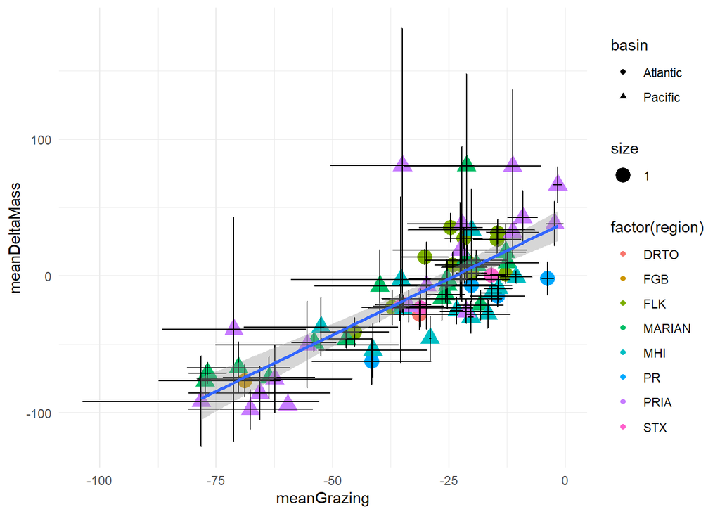

## Atlantic and Caribbean:

**deltaMass_mgcm2y boxplots by region and subregion**

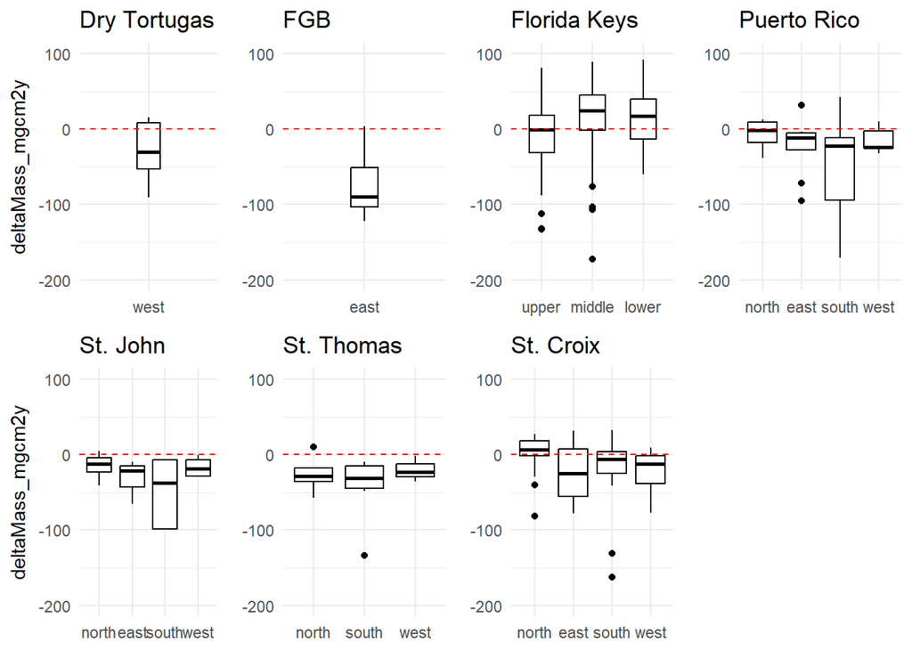

**Macroboring boxplots by region and subregion**

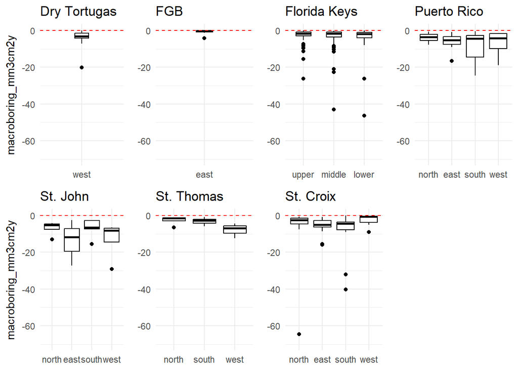

**Grazing boxplots by region and subregion**  
*Note that the initial volumes are missing for some USVI and PR data, thereby removing some of those grazing values.

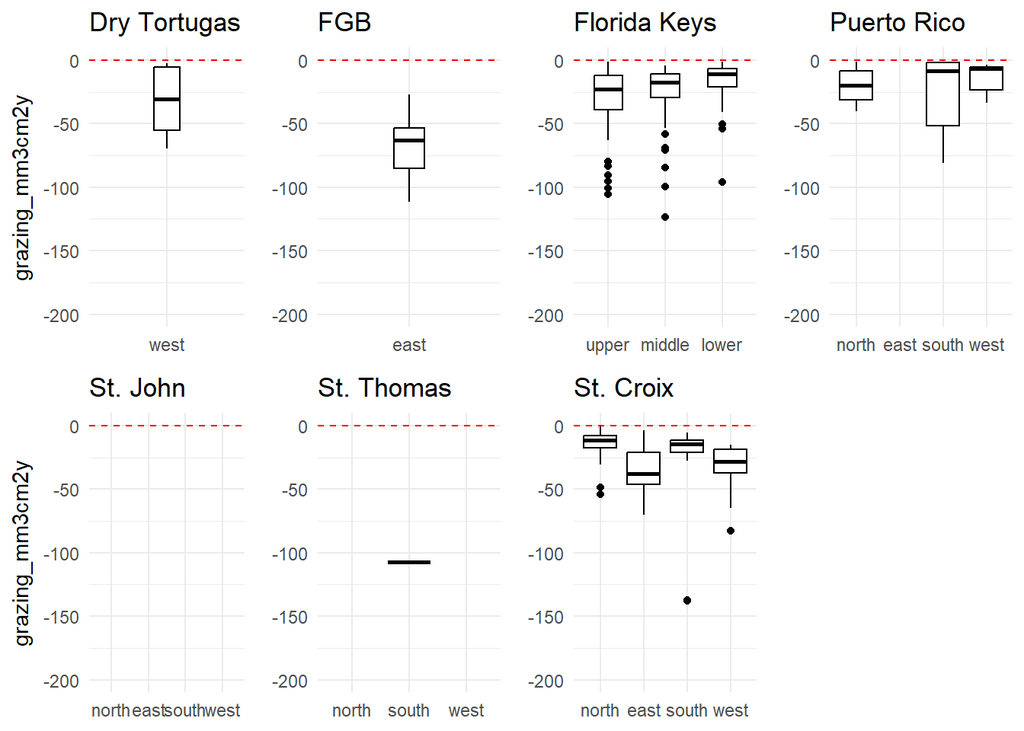

**Accretion boxplots by region and subregion**

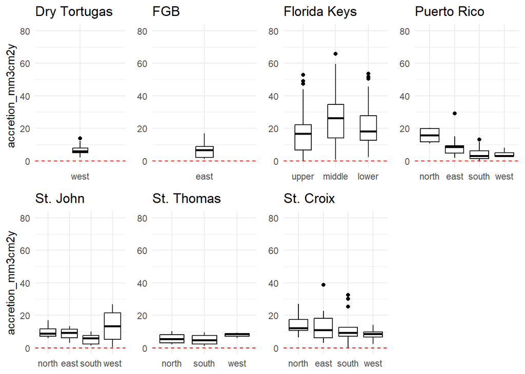